# A Practical Primer on Processing Semantic Property Norm Data

Erin M. Buchanan, Simon De Deyne, & Maria Montefinese

11/13/2019

# What is the property norm task?

- Participants are given a list of cue words and asked to list properties of those cue words
- Largely influential data for studying semantic representation and meaning, calculating various measures of similarity, feature informativeness, significance, and richness
- Standardized stimuli are very useful!

# Examples of the property norm task

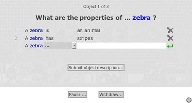

# Examples of the property norm task

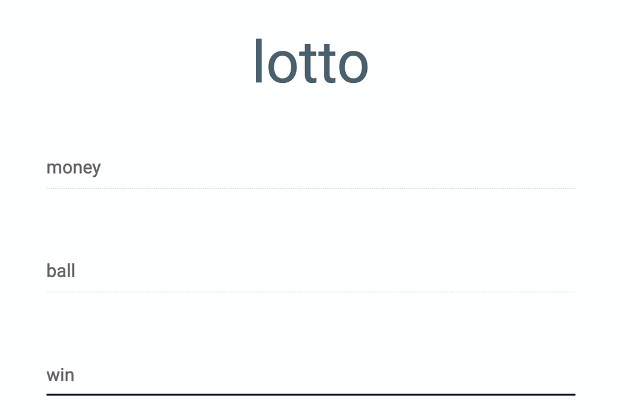

# Why should we automate data processing?

- Reproducibility, Openness, Transparency
- Allow for different processing approaches on the same data
- Reduced load on lab collecting data

# Suggested processing

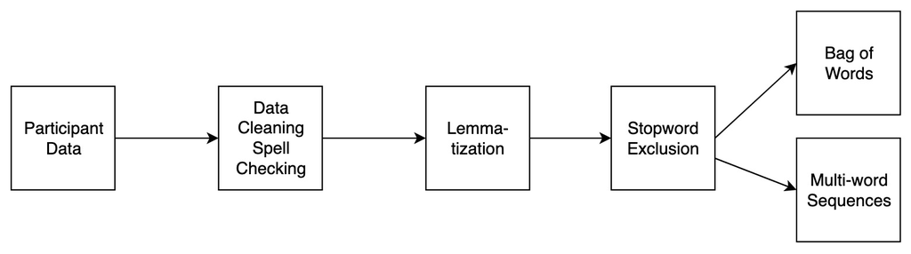

# Example data and output

Example of Data Formatted for Tidy Data

| Cue | Participant Answer |
| --- | --- |
| airplane | you fly in it its big it is fast they are expensive they are at an airport you have to be trained to fly it there are lots of seats they get very high up |
| airplane | wings engine pilot cockpit tail |
| airplane | wings it flys modern technology has passengers requires a pilot can be dangerous runs on gas used for travel |
| airplane | wings flys pilot cockpit uses gas faster travel |
| airplane | wings engines passengers pilot(s) vary in size and color |
| airplane | wings body flies travel |

# Spelling and Other Text Considerations

- Remove double letters and other text speech `finalllllyyyyy` (`stringr`)
- Remove contractions and other symbols (`textclean`)
- Spell check the data (`hunspell`)

Example Spelling Dictionary

| Spelling Error | Suggestion |
| --- | --- |
| flys | fly |
| transportaion | transportation |
| firey | fiery |
| neccessety | necessity |
| cigerate | refrigerate |
| dont | font |

# Lemmatization

- Stemming versus lemmatization (`tm` vs `korPus` or `textstem`)
- TreeTagger can be difficult to set up, but presents many language models
- If you are willing to mix and match with `python`, `spacyr` is the `R` wrapper for `spaCy`

Lemma and Part of Speech (POS) Information from TreeTagger

| Cue | Feature | POS | Lemma |
| --- | --- | --- | --- |
| airplane | is | verb | be |
| airplane | fast | adverb | fast |
| airplane | they | pronoun | they |
| airplane | are | verb | be |
| airplane | expensive | adjective | expensive |
| airplane | they | pronoun | they |

# Stopwords

- You guys know what stopwords are
- Should we remove stopwords?
- However, one should be explicit about their removal of stopwords because:
  - `stopwords()`: includes ~ 175
  - `tm()`: options for nearly 600 words

```
## [1] "i"      "me"     "my"     "myself" "we"     "our"
```

```
## [1] "a"         "a's"       "able"      "about"     "above"     "according"
```

# Processing Type

- Multiword sequences: if you collect data in a practical way, you would simply use the finalized “clean” version of the data to combine for analysis
  - Stopwords may allow of fuzzy matching for ontology labels
- Bag of Words approach: `tidytext` presents many great functions for grouping and combining lemmas to create cue-feature lists

# Finalized Data

- Idiosyncratic responses: by providing the complete feature lists, one may decide what level of response is necessary for their project

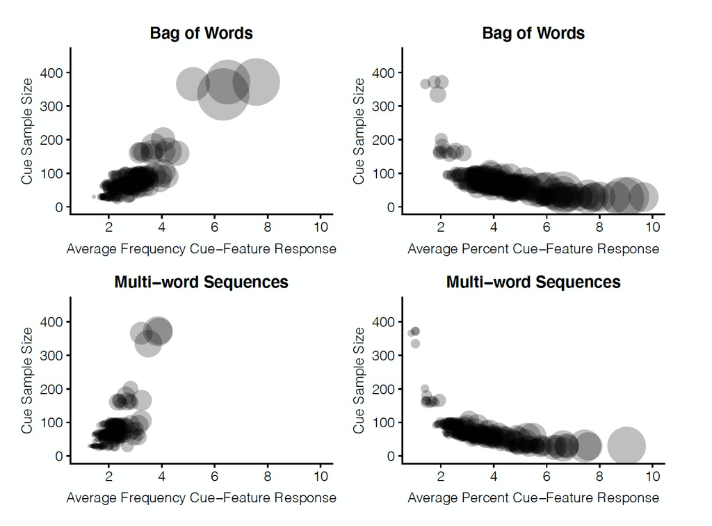

# Does it work?

- Correlation with MEN dataset ratings is *r*s .54 (multiword) and .70 (bag of worlds)
- Positive agreement with previous analysis of this dataset

Cosine Overlap with Previous Data Collection

| Statistic | With Stopwords Original | With Stopwords Translated | No Stopwords Original | No Stopwords Translated |
| --- | --- | --- | --- | --- |
| B Mean | 0.55 | 0.58 | 0.69 | 0.74 |
| B SD | 0.16 | 0.16 | 0.16 | 0.15 |
| M Mean | 0.33 | 0.50 | 0.39 | 0.59 |
| M SD | 0.15 | 0.13 | 0.18 | 0.13 |
| V Mean | 0.50 | 0.50 | 0.60 | 0.59 |
| V SD | 0.18 | 0.18 | 0.18 | 0.19 |

# Learn the code

- Google Statistics of DOOM
  - Practical primer code explanation
  - https://www.youtube.com/embed/FbznaCOXbcU
  - Natural Language Processing tutorials in R and Python posted weekly

# Thanks!

- Questions?